# Встреча Байеса и Ципфа, или Как измерить различия в частотности слов

Кирилл Маслинский

## Генерация искусственных распределений

### Подготовка базового лексического распределения на основе Деткорпуса

Основа для генерации — частотный список лемм из Деткорпуса — Корпуса русской прозы для детей и юношества XX-XXI вв. (http://detcorpus.ru).

```r
library(readr)
library(dplyr)
```

```r
library(ggplot2)
dcfreq <- read_csv("data/detcorpus-freqlist.csv") |>
    filter(!is.na(lemma)) |>
    mutate(ipm = Freq/sum(Freq)*1e6)
```

Частотные слова:

```r
head(dcfreq)
```

```
## # A tibble: 6 × 3
##   lemma    Freq    ipm
##   <chr>   <dbl>  <dbl>
## 1 и     2884904 36135.
## 2 в     1885078 23611.
## 3 не    1754134 21971.
## 4 на    1425859 17859.
## 5 он    1410058 17662.
## 6 я     1320033 16534.
```

Редкие слова:

```r
tail(dcfreq, 30)
```

```
## # A tibble: 30 × 3
##    lemma          Freq    ipm
##    <chr>         <dbl>  <dbl>
##  1 зафурмыкать       1 0.0125
##  2 блюкнуть          1 0.0125
##  3 астралиец         1 0.0125
##  4 одождать          1 0.0125
##  5 зафутболивать     1 0.0125
##  6 зафурыкать        1 0.0125
##  7 яэто              1 0.0125
##  8 одолжениии        1 0.0125
##  9 одоливать         1 0.0125
## 10 одолженьице       1 0.0125
## # ℹ 20 more rows
```

Объем лексикона:

```r
V <- nrow(dcfreq)
V
```

```
## [1] 244141
```

Объем корпуса:

```r
N <- sum(dcfreq$Freq)
N
```

```
## [1] 79837890
```

Оценка вероятности, что следующее слово в корпусе окажется новым (оценка скорости роста словаря в корпусе такого объема). Рассчитывается как доля hapax legomena (слов с частотностью == 1) в корпусе:

```r
V1 <- sum(dcfreq$Freq==1)
V1/N
```

```
## [1] 0.001185653
```

Для того чтобы учесть слова, которые не встретились в корпусе, добавим псевдослово «HAPAX» с вероятностью по приведенной выше оценке.

```r
dcfreq.p <- rbind(dcfreq, list(lemma="HAPAX", Freq=V1, ipm=V1/V*1e6)) %>%
    mutate(p = Freq/sum(Freq))
```

Обратите внимание, что наше псевдослово обладает значительно более высокой вероятностью, чем каждый отдельный hapax legomena, потому что представляет вероятность появления *любого* ранее не встречавшегося в корпусе слова.

```r
tail(dcfreq.p)
```

```
## # A tibble: 6 × 4
##   lemma    Freq         ipm            p
##   <chr>   <dbl>       <dbl>        <dbl>
## 1 Dangée1     1      0.0125 0.0000000125
## 2 AF₂         1      0.0125 0.0000000125
## 3 A5          1      0.0125 0.0000000125
## 4 A3          1      0.0125 0.0000000125
## 5 A11         1      0.0125 0.0000000125
## 6 HAPAX   94660 387727.     0.00118
```

Для воспроизводимости зафиксируем случайные числа:

```r
set.seed(89)
```

### Создание двух синтетических «корпусов»

Построим две случайных выборки по 100 тыс слов каждая, используя в качестве вероятностного распределения слов одно и то же распределение Деткорпуса.

```r
c1 <- sample(dcfreq.p$lemma, size=1e5, replace=TRUE, prob=dcfreq.p$p)
c1[c1=="HAPAX"] <- paste0("hapax", sample(1:1e4, sum(c1=="HAPAX")))
c2 <- sample(dcfreq.p$lemma, size=1e5, replace=TRUE, prob=dcfreq.p$p)
c2[c2=="HAPAX"] <- paste0("hapax", sample(1:1e4, sum(c2=="HAPAX")))
```

Частотные списки:

```r
c1.f <- tibble(lemma=c1) %>% count(lemma, sort=TRUE)
c2.f <- tibble(lemma=c2) %>% count(lemma, sort=TRUE)
```

Объединим частотные списки в один

```r
c.both <- bind_rows(c1=c1.f, c2=c2.f, .id="corpus")
```

Составим сравнительную таблицу

```r
library(tidyr)
c.wide <- c.both %>%
    group_by(corpus) %>%
    pivot_wider(names_from = corpus, values_from = n, values_fill = 0)
```

Слова, которые встретились только в одном из корпусов:

```r
c.n0 <- c.wide %>%
    filter(c1 == 0 | c2 == 0)
```

### Призрак значимости: log likelihood

Определим функцию для вычисления Dunning log-likelihood (G^2):

```r
g2 = function(a, b) {
  c = sum(a)
  d = sum(b)
  E1 = c * ((a + b) / (c + d))
  E2 = d * ((a + b) / (c + d))
  return(2*((a*log(a/E1+1e-7)) + (b*log(b/E2+1e-7))))
}
```

Добавим значение G2, отсортируем по его величине:

```r
c.ll <- c.wide %>%
    mutate(g2 = g2(c1, c2)) %>%
    arrange(desc(g2))
c.ll
```

```
## # A tibble: 21,965 × 4
##    lemma          c1    c2    g2
##    <chr>       <int> <int> <dbl>
##  1 топать         10     0 13.9
##  2 художник       14     1 13.4
##  3 асфальт         9     0 12.5
##  4 победа          9     0 12.5
##  5 стадо           9     0 12.5
##  6 одиночество     8     0 11.1
##  7 вцепляться      0     8 11.1
##  8 шестой          0     8 11.1
##  9 глубоко         1    12 11.0
## 10 поводить       16     3  9.77
## # ℹ 21,955 more rows
```

Всего слов, превышающих значение G2 3.84 (соответствует уровню значимости 0.05):

```r
c.ll |>
    filter(g2>=3.84) |> nrow()
```

```
## [1] 819
```

Зависимость между частотностью слова и значением G2

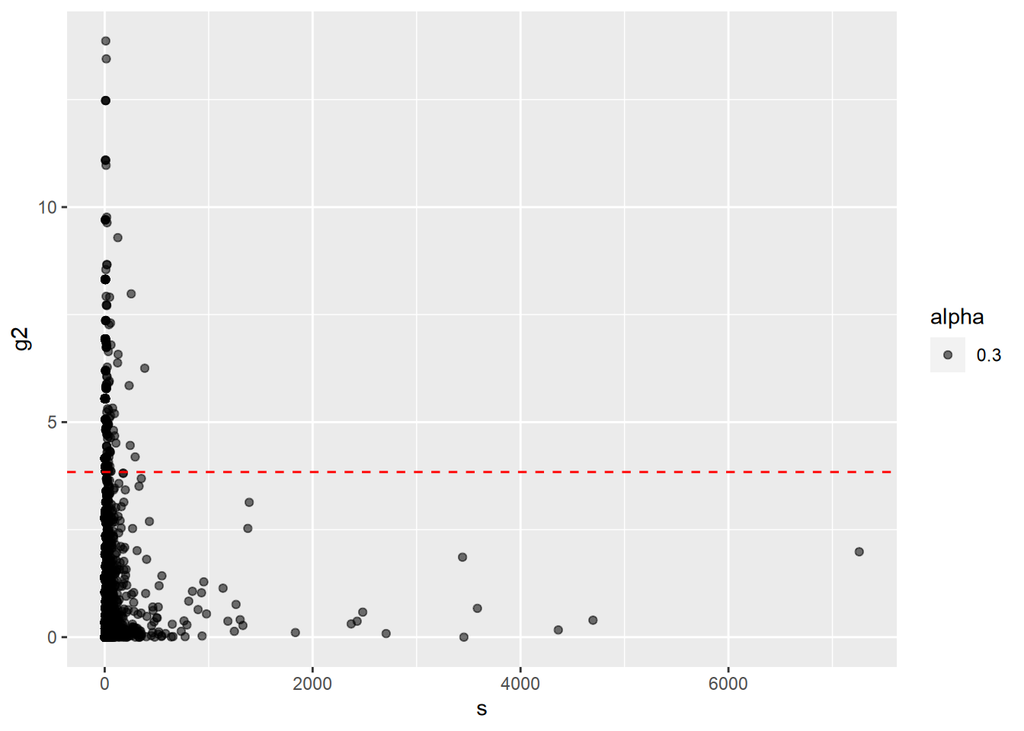

```r
c.ll %>%
    mutate(s = c1+c2) %>%
    ggplot(aes(y = g2, x = s, alpha = 0.3)) +
    geom_point() + geom_hline(yintercept=3.84, color="red", lty=2)
```

Бинаризованный график в логарифмической шкале частотностей

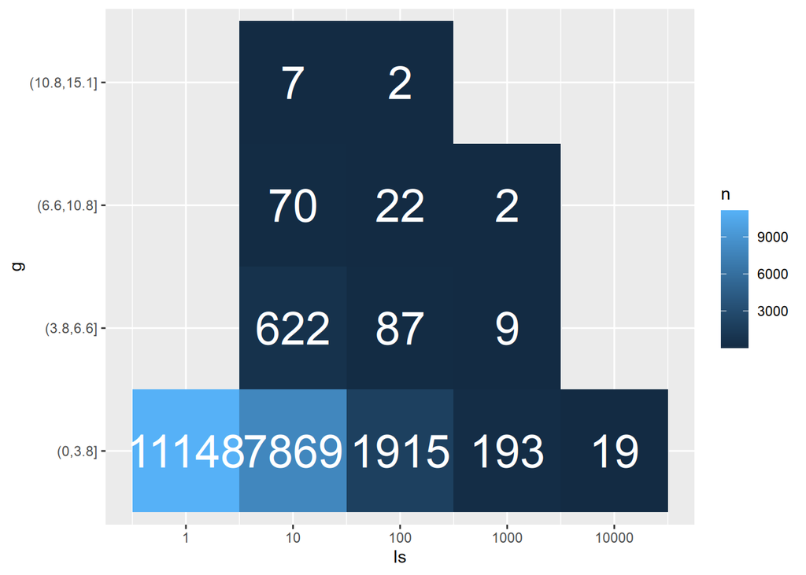

```r
c.ll %>%
    mutate(s = c1+c2) %>%
    mutate(ls = 10^ceiling(log10(s))) %>%
    mutate(g = cut(g2, breaks = c(0, 3.8, 6.6, 10.8, 15.1, 100))) %>%
    count(g, ls) %>%
    ggplot(aes(y = g, x = ls, fill = n)) + geom_tile() +
    geom_text(aes(label = n), color = "white", size = 10) +
    scale_x_log10()
```

### Искусственная разница

Создадим теперь два искусственных корпуса с различной вероятностью слов. Для наглядности сделаем так, что во втором корпусе все слова на букву «ц» вдвое более вероятны, чем в первом корпусе.

Самые частотные слова на букву ц

```r
library(stringr)
dcfreq %>% filter(str_detect(lemma, "^ц.*")) %>% head(20)
```

```
## # A tibble: 20 × 3
##    lemma        Freq   ipm
##    <chr>       <dbl> <dbl>
##  1 целый       27377 343.
##  2 цветок      13009 163.
##  3 цвет         9919 124.
##  4 центр        7228  90.5
##  5 цель         7074  88.6
##  6 царь         5321  66.6
##  7 цепь         4927  61.7
##  8 церковь      4836  60.6
##  9 цирк         4059  50.8
## 10 цифра        3786  47.4
## 11 цена         3639  45.6
## 12 цех          3009  37.7
## 13 цепочка      2849  35.7
## 14 цветной      2763  34.6
## 15 центральный  2681  33.6
## 16 ценный       2588  32.4
## 17 цыпочки      2491  31.2
## 18 целовать     2267  28.4
## 19 цепляться    2078  26.0
## 20 царский      1931  24.2
```

Модифицируем частотности и вычисляем вероятности

```r
dc.tse <- dcfreq %>%
    mutate(f2 = ifelse(str_detect(lemma, "^ц.*"), Freq*2, Freq)) %>%
    mutate(p1 = Freq/sum(Freq), p2 = f2/sum(f2)) %>%
    select(lemma, f1 = Freq, f2, p1, p2)
```

Для удобства определим функцию, которая сразу возвращает частотный список по списку лемм и вероятностей:

```r
generate_freqlist <- function(n, lemmas, prob) {
    c1 <- sample(lemmas, size=n, replace=TRUE, prob=prob)
    nhapax <- sum(c1=="HAPAX")
    c1[c1=="HAPAX"] <- sample(1:(2*nhapax), nhapax)
    tibble(lemma=c1) %>% count(lemma, sort=TRUE)
}
```

Сгенерируем два новых частотных списка и объединим их в общую таблицу:

```r
s1 <- generate_freqlist(1e5, dc.tse$lemma, dc.tse$p1)
s2 <- generate_freqlist(1e5, dc.tse$lemma, dc.tse$p2)
s.wide <- bind_rows(c1=s1, c2=s2, .id="corpus") %>%
    group_by(corpus) %>%
    pivot_wider(names_from = corpus, values_from = n, values_fill = 0)
```

Рассчитаем G2:

```r
s.ll <- s.wide %>%
    mutate(g2 = g2(c1, c2)) %>%
    arrange(desc(g2))
s.ll
```

```
## # A tibble: 21,561 × 4
##    lemma          c1    c2    g2
##    <chr>       <int> <int> <dbl>
##  1 целый          37    76 13.7
##  2 бесконечный     9     0 12.5
##  3 выписывать      0     9 12.5
##  4 гнездо          0     9 12.5
##  5 крупный        16     2 12.4
##  6 паспорт         8     0 11.1
##  7 вновь           4    19 10.6
##  8 гордо          11     1  9.75
##  9 листок          1    11  9.75
## 10 мешок          22     6  9.72
## # ℹ 21,551 more rows
```

Посмотрим результаты G2 только по словам на ц-:

```r
s.ll %>% filter(str_detect(lemma, "^ц.*")) %>% head()
```

```
## # A tibble: 6 × 4
##   lemma       c1    c2    g2
##   <chr>    <int> <int> <dbl>
## 1 целый       37    76 13.7
## 2 царевна      0     5  6.93
## 3 целиться     0     5  6.93
## 4 целое        0     5  6.93
## 5 цветок      12    28  6.58
## 6 цвести       2    10  5.82
```

Количество слов на ц-, не превысивших значение 3.84 (соответствующее уровню значимости 0.05):

```r
s.ll |>
    filter(str_detect(lemma, "^ц.*")) |>
    mutate(signif = g2 >= 3.84) |>
    count(signif)
```

```
## # A tibble: 2 × 2
##   signif     n
##   <lgl>  <int>
## 1 FALSE    109
## 2 TRUE      16
```

Иллюстрация, где слова на ц- выделены красным:

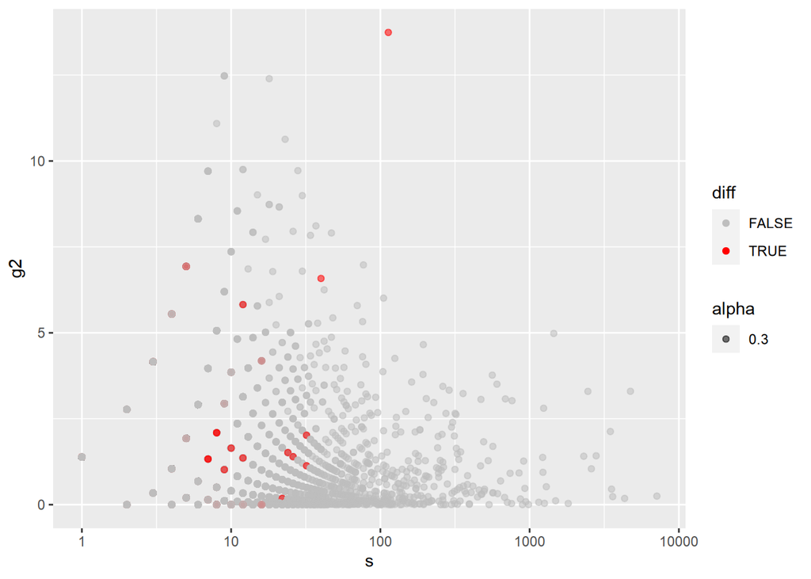

```r
s.ll %>%
    mutate(s = c1+c2) %>%
    mutate(diff = ifelse(str_detect(lemma, "^ц.*"), TRUE, FALSE)) %>%
    ggplot(aes(y = g2, x = s, alpha = 0.3, color = diff)) + geom_point() +
    scale_color_manual(values = c("gray", "red")) +
    scale_x_log10()
```

То же, с порогами отсечения:

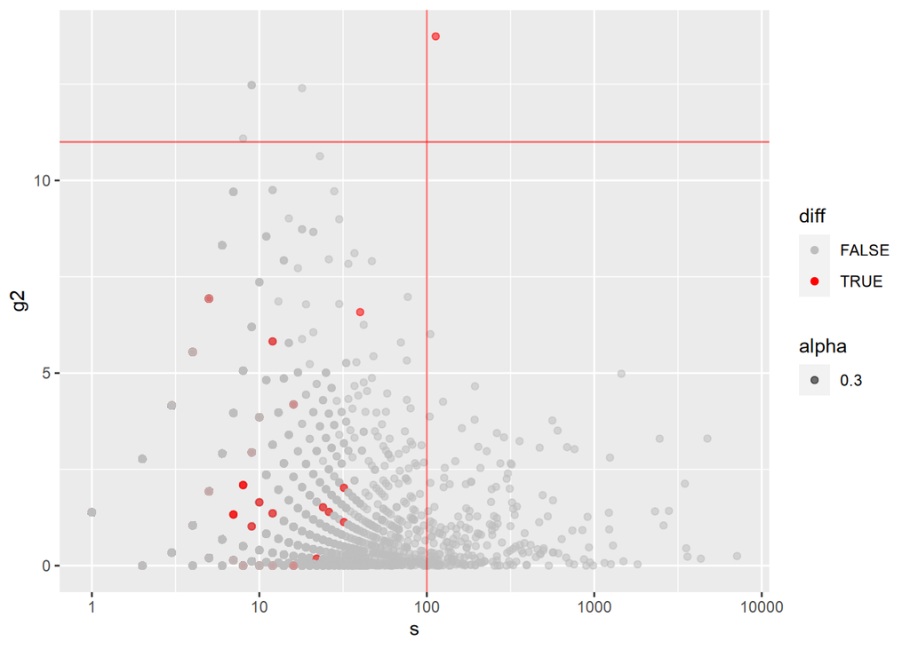

```r
s.ll %>%
    mutate(s = c1+c2) %>%
    mutate(diff = ifelse(str_detect(lemma, "^ц.*"), TRUE, FALSE)) %>%
    ggplot(aes(y = g2, x = s, alpha = 0.3, color = diff)) + geom_point() +
    scale_color_manual(values = c("gray", "red")) +
    scale_x_log10() +
    geom_hline(yintercept = 11, color = "red", alpha = 0.5) +
    geom_vline(xintercept = 100, color = "red", alpha = 0.5)
```

## Simple maths Адама Килгариффа

Сначала рассмотрим на примере одинаковых сгенерированных корпусов без различий в вероятности слов. Сразу используем разные константы: +1 и +100.

```r
c.sm <- c.wide %>%
    mutate(sm1 = (c1+1)/(c2+1), sm100 = (c1+100)/(c2+100)) %>%
    mutate(s = c1+c2) %>%
    arrange(desc(sm1))
```

График соотношения значений sm1 и sm100 и суммарной частотности слова в случае отсутствия различий в вероятности слов при генерации корпуса.

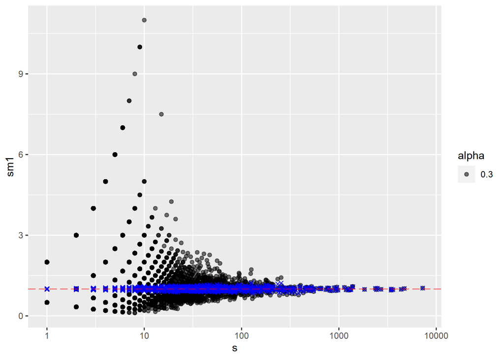

```r
c.sm %>%
    ggplot(aes(x = s, y = sm1, alpha = 0.3)) +
    geom_point() +
    geom_point(aes(y = sm100), shape = 4, color = "blue", alpha=1)  +
    geom_hline(yintercept = 1, linetype = "longdash", alpha = 0.5, color = "red") +
    scale_x_log10()
```

Теперь посмотрим на корпусе, где заложены различия в вероятностях слов.

```r
s.sm <- s.wide %>%
    mutate(sm1 = (c2+1)/(c1+1), sm100 = (c2+100)/(c1+100)) %>%
    mutate(s = c1+c2) %>%
    arrange(desc(sm1))
```

График для sm1

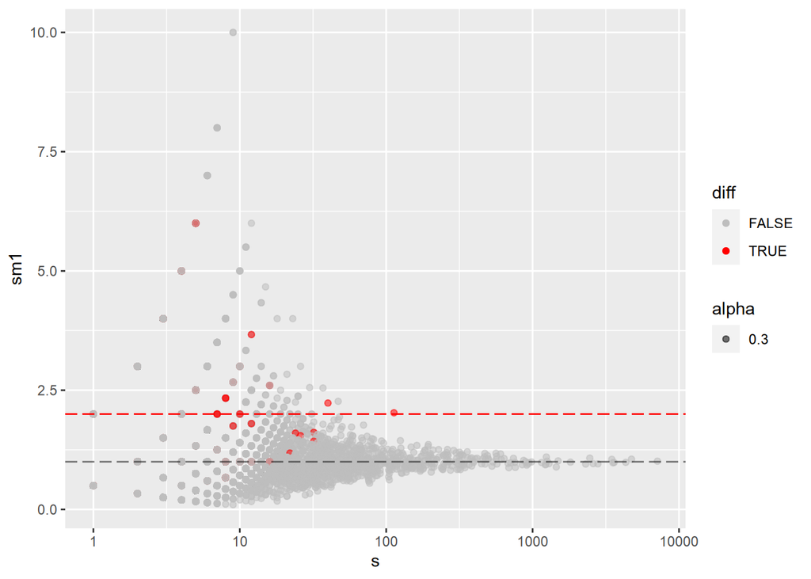

```r
s.sm %>%
    mutate(diff = ifelse(str_detect(lemma, "^ц.*"), TRUE, FALSE)) %>%
    ggplot(aes(x = s, y = sm1, alpha = 0.3, color = diff)) +
    geom_point() +
    geom_hline(yintercept = 1, linetype = "longdash", alpha = 0.5, color = "black") +
    geom_hline(yintercept = 2, linetype = "longdash", alpha = 1, color = "red") +
    scale_x_log10() +
    scale_color_manual(values = c("gray", "red"))
```

То же, для sm100

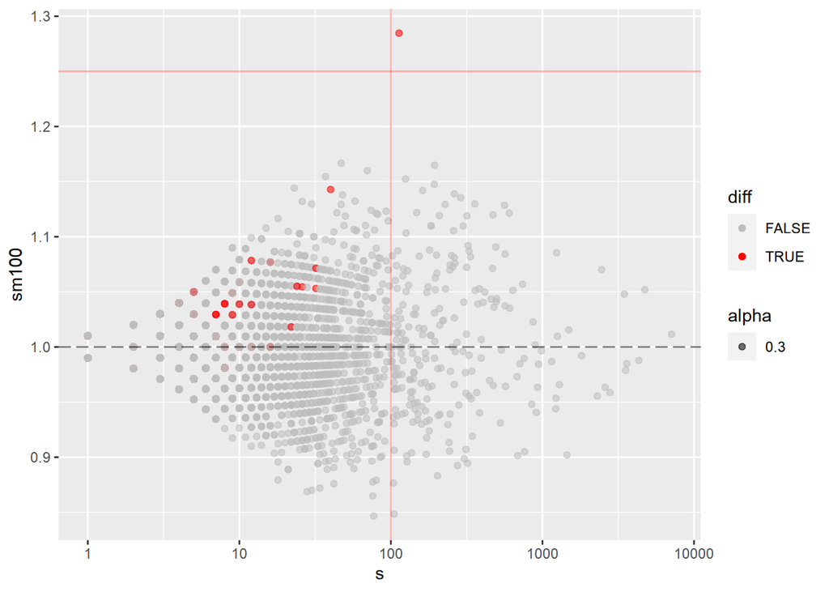

```r
s.sm %>%
    mutate(diff = ifelse(str_detect(lemma, "^ц.*"), TRUE, FALSE)) %>%
    ggplot(aes(x = s, y = sm100, alpha = 0.3, color = diff)) +
    geom_point() +
    geom_hline(yintercept = 1, linetype = "longdash", alpha = 0.5, color = "black") +
    geom_vline(xintercept = 100, alpha = 0.3, color = "red") +
    geom_hline(yintercept = 1.25, alpha = 0.3, color = "red") +
    scale_x_log10() +
    scale_color_manual(values = c("gray", "red"))
```

## Байесовские модели

```r
library(rethinking)
```

### Пуассоновская модель для отдельной леммы

```r
flower.rnc <- 32028/374449975*1e5
flower.rnc
```

```
## [1] 8.553345
```

```r
16020/150820022*1e6 # художественная литература
```

```
## [1] 106.2193
```

```r
16008/223628838*1e6 # нон-фикшн
```

```
## [1] 71.5829
```

Данные — частотность леммы «цветок» в двух корпусах.

```r
dflower.same <- list(freq=c(9, 17), corpus=c(1, 2), rnc = flower.rnc)
dflower.diff <- list(freq=c(12, 28), corpus=c(1, 2), rnc = flower.rnc)
```

Простая пуассоновская модель, в которой частотность леммы определяется ее фоновой частотностью в большом корпусе (оцененной, например, по НКРЯ) и специфической корректировкой для каждого из подкорпусов.

```r
m1formula <- alist(
    freq ~ dpois( lambda ),
    lambda <- a * b[corpus],
    a ~ dnorm(rnc, 0.5),
    b[corpus] ~ dexp(1)
)
```

Оценка для корпусов с равной вероятностью цветка:

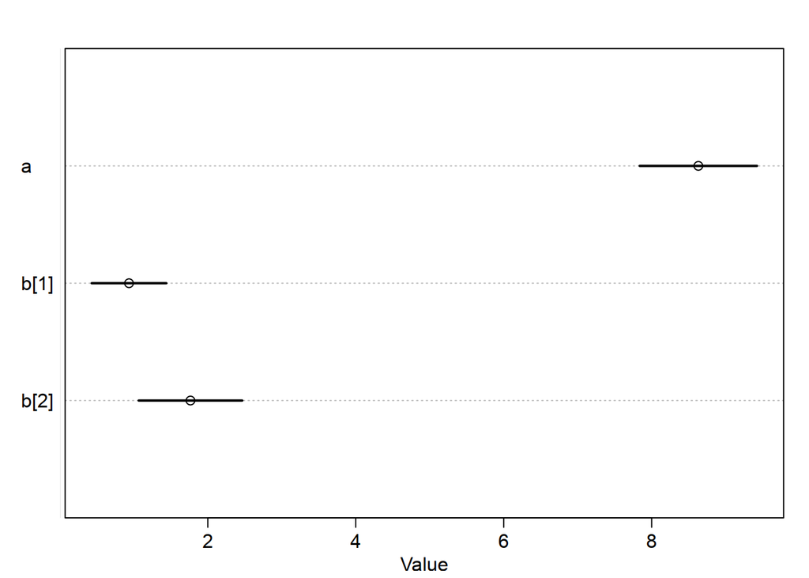

```r
m1.same <- quap(m1formula, data=dflower.same)
plot(precis(m1.same, depth=2))
```

Оценка для корпусов с различной вероятностью цветка:

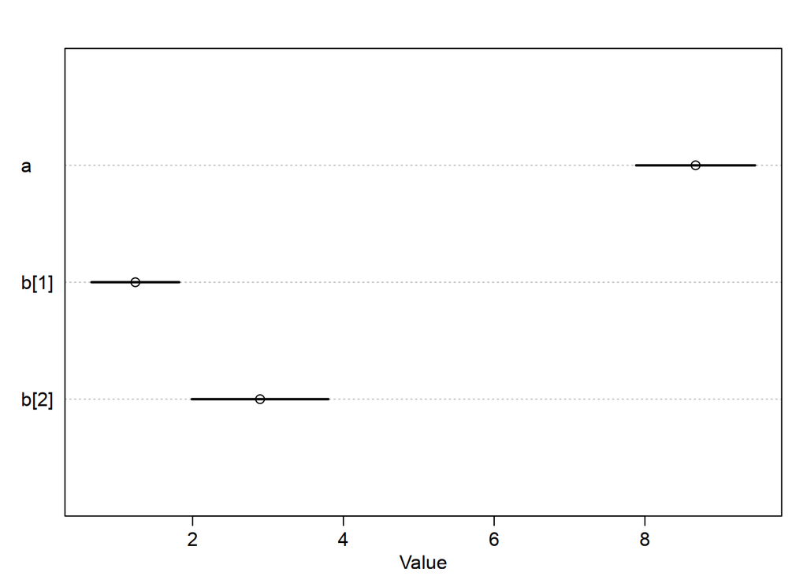

```r
m1.diff <- quap(m1formula, data=dflower.diff)
plot(precis(m1.diff, depth=2))
```

Менее частотная лемма «цыган», для которой в наших данных существует различие вероятностей:

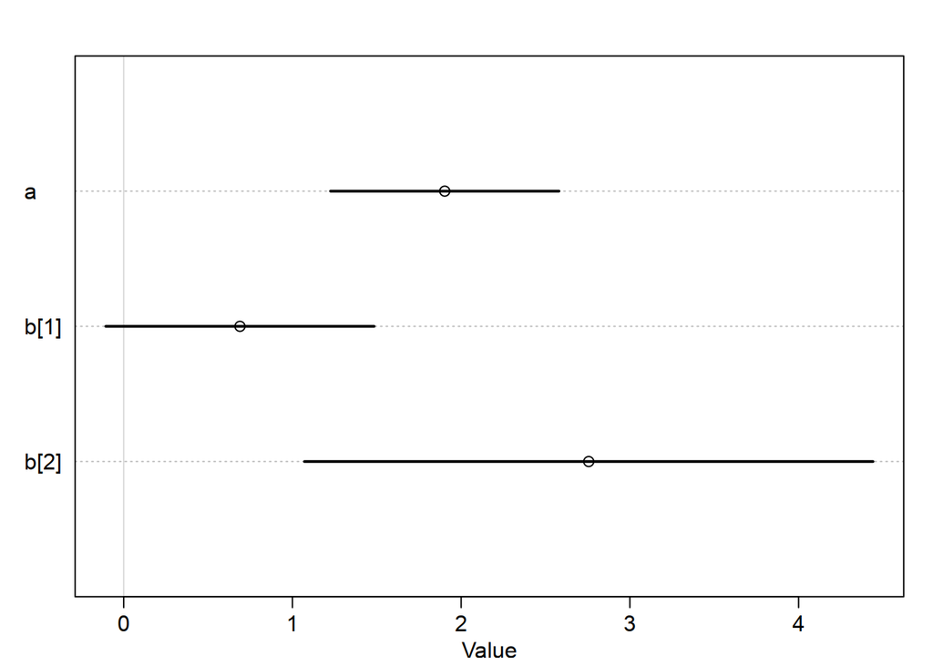

```r
m1.1 <- quap(m1formula, data=list(freq=c(2, 8), corpus=c(1, 2), rnc = 1.45))
plot(precis(m1.1, depth=2))
```

Менее частотная лемма «листок», для которой в наших данных отсутствует различие вероятностей:

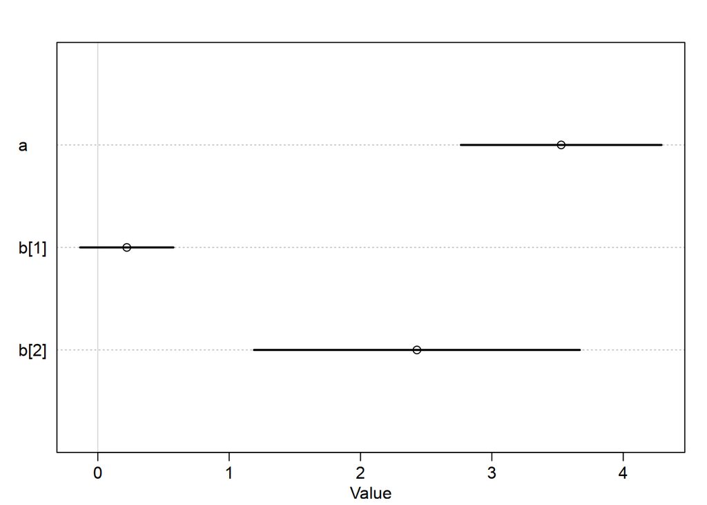

```r
m1.2 <- quap(m1formula, data=list(freq=c(1, 11), corpus=c(1, 2), rnc = 3.34))
plot(precis(m1.2, depth=2))
```

Более строгое (регуляризующее) априорное распределение для отклонений частотности между корпусами:

```r
m1aformula <- alist(
    freq ~ dpois( lambda ),
    lambda <- a * b[corpus],
    a ~ dnorm(rnc, 0.5),
    b[corpus] ~ dnorm(1, 0.5)
)
```

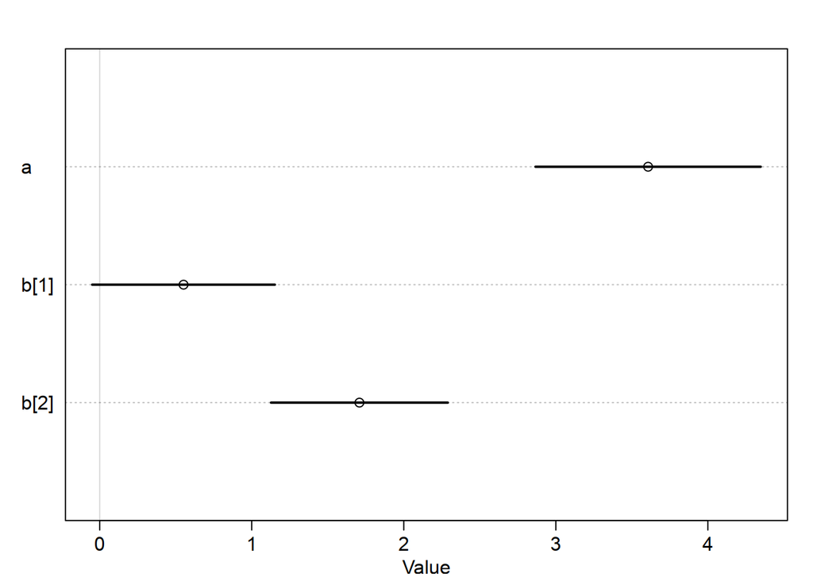

```r
m1a.2 <- quap(m1aformula, data=list(freq=c(1, 11), corpus=c(1, 2), rnc = 3.34))
plot(precis(m1a.2, depth=2))
```

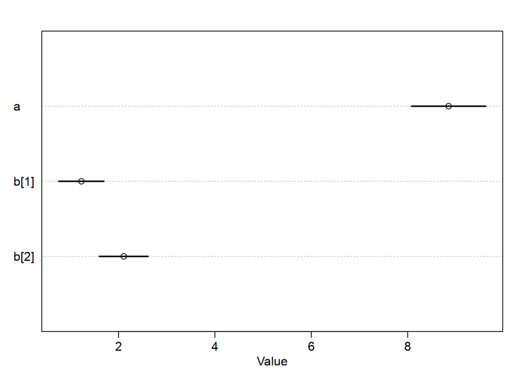

```r
m1a.diff <- quap(m1aformula, data=dflower.diff)
plot(precis(m1a.diff, depth=2))
```